# qicharts2

February 2020

## Questions

### Because I always forget this part…

- Who uses Statistical Process Control charts?

  (or run charts and funnel plots)
- Who has used qicharts2 package in R?

## Package details

```r
install.packages("qicharts2")

library(qicharts2)
```

- Available on CRAN
- Comes with sample healthcare datasets
- Created by Jacob Anhøj, a doctor in Denmark
- Supercedes qichart package

## Why I like this package …

## Reasons to be joyful

- I skim instructions
- I just *get* healthcare data (not plants and certainly not cars)
- Reproducible examples in the vignette
- More than one type of SPC available

## Like this

### Snapshot of the vignette:

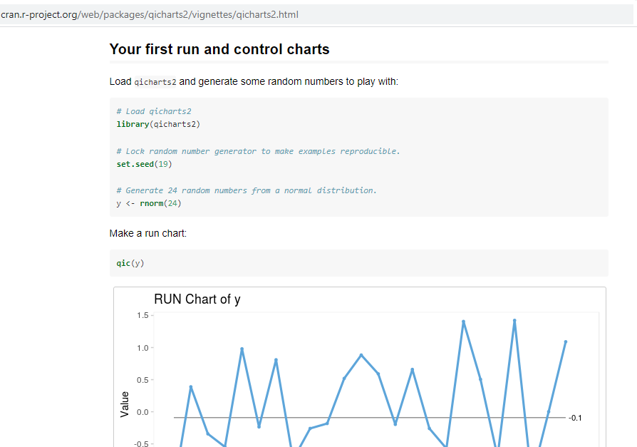

## Nightingale’s Crimea…

## Getting data

Copied data manually from: https://understandinguncertainty.org/node/214

library(datapasta) to copy directly to R

Saved in a script for quick retrieval later

```r
source("Crimea.R")
```

## Being #rstats though

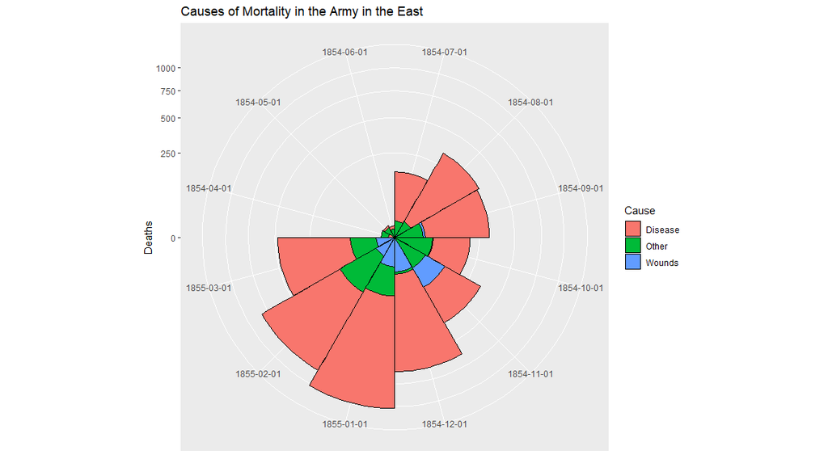

```r
install.packages("HistData")

library(HistData)

data("Nightingale")
```

## Replot in qicharts2

## Run chart code

Built on ggplot2

```r
qic(startMonth,number,
    data     = crimeaLong,
    chart    = 'run',
    decimals = 0,

    x.angle  = 90,
    title    = 'Run chart deaths in Crimea War',
    ylab     = 'Number of deaths',
    xlab     = 'Month'
)
```

## Produces this

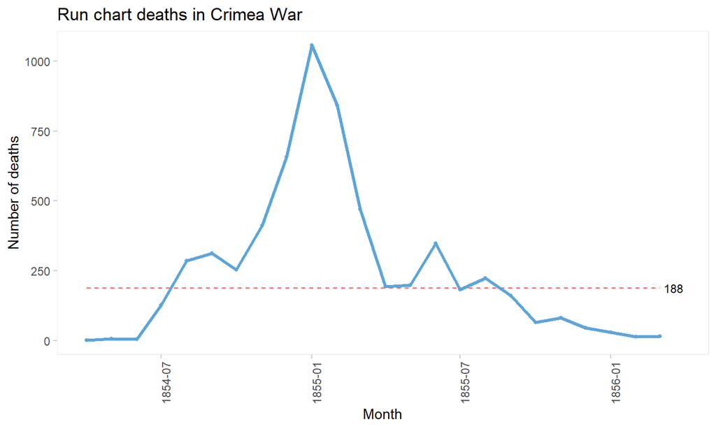

## Sprinkle ggplot2 magic…

## Facets

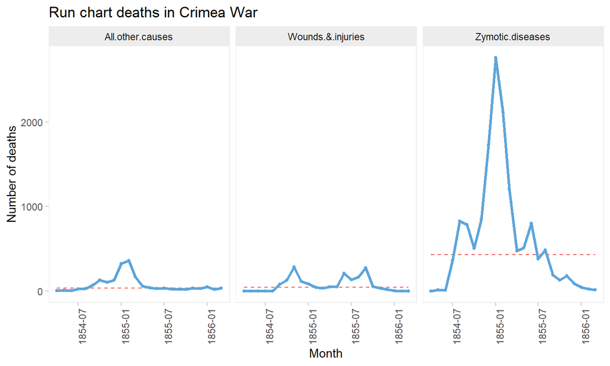

## Just imagine…

Producing…

- 30 incident categories
- 10 wards
- 25 LSOAs

To look for signals

## The magic is one line of code

```r
qic(startMonth,number,
    data     = crimeaLong,
    chart    = 'run',
    decimals = 0,

    x.angle  = 90,
    title    = 'Run chart deaths in Crimea War',
    ylab     = 'Number of deaths',
    xlab     = 'Month'
)
```

## With the facet line

```r
qic(startMonth,number,
    data     = crimeaLong,
    chart    = 'run',
    decimals = 0,
    facets   = ~death_cause,
    x.angle  = 90,
    title    = 'Run chart deaths in Crimea War',
    ylab     = 'Number of deaths',
    xlab     = 'Month'
)
```

## Moving Range SPC

```r
qic(startMonth,number,
    data     = crimeaLong,
    chart    = 'mr',
    decimals = 0,
    facet    = ~death_cause,
    x.angle  = 90,
    title    = 'SPC mr chart deaths in Crimea War',
    ylab     = 'Number of deaths',
    xlab     = 'Month'
)
```

## mr Chart (or is that Mr Chart!)

As seen on Twitter @Letxuga007

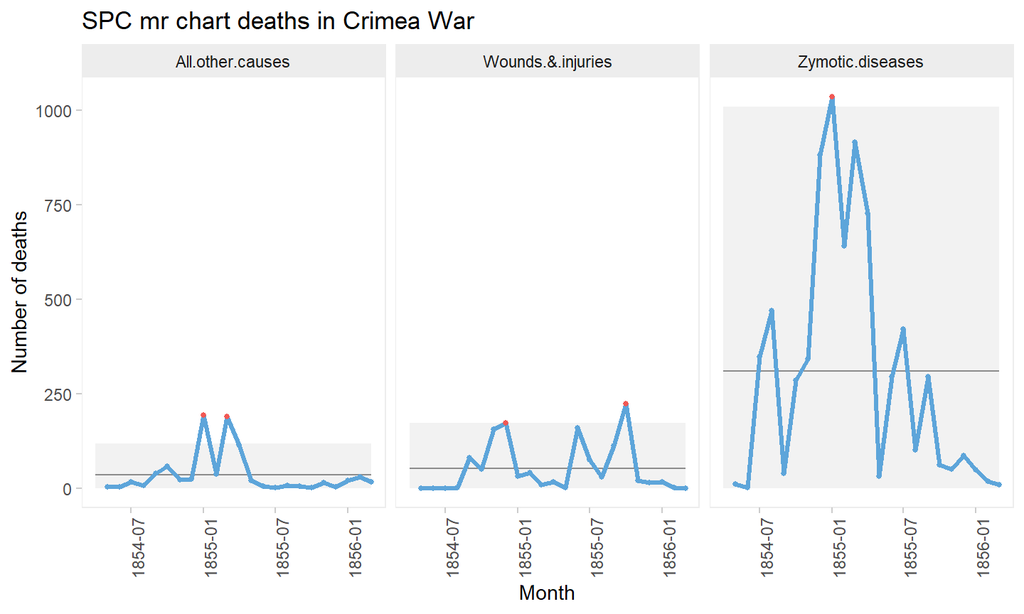

## Other SPC charts are available

## Rare events - time between

The code requires a count of days difference.

Cabg = coronary artery bypass operations

```r
# Altered slightly from the vignette

fatalities <- cabg %>%
  filter(death) %>%
  mutate(dt = date - lag(date))
```

## T-chart

A point above the upper control limit is a good thing!

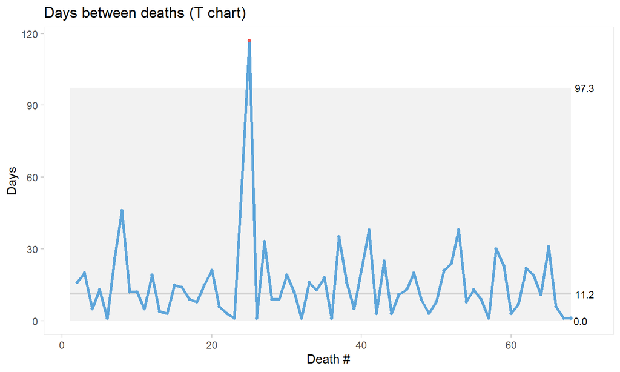

## Breaking into the chart

## Getting the data

The numbers generated to create the charts can be viewed/saved by typing:

```r
newObject <- tchart$data
```

## When is this useful?

In this blog: https://www.r-bloggers.com/backed-by-data/ @_johnmackintosh shows how to:

- tweak the charts

- to include only those charts with a signal

## Other interesting things

## Further information

Jacob has created this Flexdashboard https://hospinf.shinyapps.io/hospinf/

SPC Shiny dashboards are being discussed on the NHS-R Slack site

- please join us and contribute

link: nhsrcommunity.slack.com

- Twitter: @NHSrCommunity
- Our Team: @DataScienceNott
- Me: @Letxuga007

Follow the hashtag #rstats